# Act report

For the followings visualizations tweets from the twitter account WeRateDogs were analyzed. This twitter account publishes short funny texts about dog images together with a usually exaggerated rating, for example 13 of 10 possible points.

```python
# import packages
import pandas as pd
import matplotlib.pyplot as plt
import matplotlib.dates
```

```python
#import data to dataframe
df = pd.read_csv('twitter_archive_master.csv')
```

First, let's have a look at the temporal evolution of favorites and retweets.

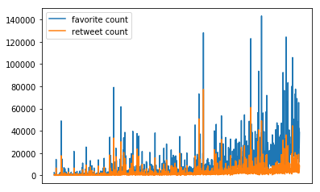

```python
fig, ax = plt.subplots()
line1, = ax.plot(df.timestamp, df.favorite_count, label='favorite count')
line2, = ax.plot(df.timestamp, df.retweet_count, label='retweet count')
ax.legend()
ax.xaxis.set_major_locator(matplotlib.dates.YearLocator(1, month = 1, day = 1))
ax.xaxis.set_major_formatter(matplotlib.dates.DateFormatter('%Y'))
plt.show()
```

The twitter account started end of 2015 and became more and more popular during the recent years, as measured in higher favorite and retweet counts in total. Here you can see that tweets that are favorited more are usually retweeted more often.

Let's check on the relationship of favorized and retweeted tweets.

```
Text(0,0.5,'Favorite Count')
```

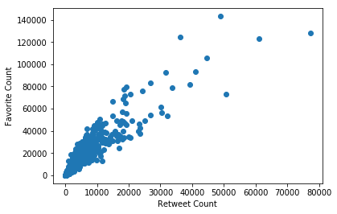

```python
plt.scatter(df.retweet_count, df.favorite_count)
axes = plt.gca()
axes.set_xlabel('Retweet Count')
axes.set_ylabel('Favorite Count')
```

Favorite and retweets seem to be positivly correlated, meaning tweets that are favorized more are more often retweeted or vice versa.

Has the rating of the dog pictures an effect on how much the images are liked (or favorized)?

```
Text(0,0.5,'Favorite Count')
```

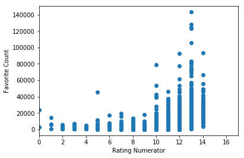

```python
plt.scatter(df.rating_numerator, df.favorite_count)
axes = plt.gca()
axes.set_xlim([0,17])
axes.set_xlabel('Rating Numerator')
axes.set_ylabel('Favorite Count')
```

It seems the rating works both, quite well and not so well. Please not here that the rating numerator axis is croped as some very super high ratings exist, which make it hard to have a nice look at the majority of the ratings. Pictures need to have a high rating by the author to get a high favorite count by the audience but not necessarly all pictures rated high by the author are liked by the audience of the twitter account.

```
Text(0,0.5,'Favorite Count')
```

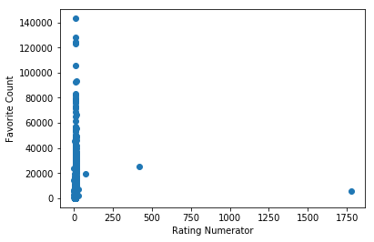

```python
plt.scatter(df.rating_numerator, df.favorite_count)
axes = plt.gca()
axes.set_xlabel('Rating Numerator')
axes.set_ylabel('Favorite Count')
```

Interestingly, tweets with an exorbitant high rating by the author of WeRateDogs are not overly favorized by the audience, meaning the audience could not comprehend the enthusiasm of the author.